# A Look at Suicide Rates Between 1985 and 2015

Oluwafunmilayo Adewole

5/17/2019

According to the web page for the dataset we’re using (https://www.kaggle.com/russellyates88/suicide-rates-overview-1985-to-2016), the inspiration for the composition of this dataset was suicide prevention, which is always a worthwhile topic. In this tutorial, I want to see if we can determine at least one potential factor in the rates of suicide in the United States and around the world, namely the wealth of a country. We’ll use hypothesis testing to draw some simple conclusions about the rates of suicide as they relate to age, sex, and a country’s wealth (GDP).

First we’re going to import some libraries that will allow us to work through our data:

```r
knitr::opts_chunk$set(echo = TRUE)
library(readr)
library(tidyverse)
library(broom)
```

## Obtaining the Data

We wouldn’t be able to do anything very useful without any data to work with, so we’ll start by grabbing the data we want to look at. I’ve chosen a dataset from Kaggle, downloaded as a .csv (comma-separated value) file. This means that each entity/piece of data is stored as a set of attribute values separated by commas. We can use the read_csv function to bring our data into our workspace, and store it into an object:

```r
suicide_info <- read_csv("~/Downloads/suicide_rates_1985_to_2016_master.csv")
suicide_info
```

```
## # A tibble: 27,820 x 12
##    country  year sex   age   suicides_no population `suicides/100k …
##    <chr>   <dbl> <chr> <chr>       <dbl>      <dbl>            <dbl>
##  1 Albania  1987 male  15-2…          21     312900             6.71
##  2 Albania  1987 male  35-5…          16     308000             5.19
##  3 Albania  1987 fema… 15-2…          14     289700             4.83
##  4 Albania  1987 male  75+ …           1      21800             4.59
##  5 Albania  1987 male  25-3…           9     274300             3.28
##  6 Albania  1987 fema… 75+ …           1      35600             2.81
##  7 Albania  1987 fema… 35-5…           6     278800             2.15
##  8 Albania  1987 fema… 25-3…           4     257200             1.56
##  9 Albania  1987 male  55-7…           1     137500             0.73
## 10 Albania  1987 fema… 5-14…           0     311000             0
## # … with 27,810 more rows, and 5 more variables: `country-year` <chr>,
## #   `HDI for year` <dbl>, `gdp_for_year ($)` <dbl>, `gdp_per_capita
## #   ($)` <dbl>, generation <chr>
```

(See notes about the data at the end of this document)

# Tidying the Data

Now let’s tidy up our data and make nice to view and easier to use.

In addition to holding two attirbutes in one column, the “country-year” column seems a bit redundant since we already have two separate columns for year and country. Also, there isn’t enough information for the yearly HDI to use for each country. We do not make any use of the generation attribute, as we are only looking at age, sex, and gdp as our attributes of interest. As such, we’ll exclude these columns from our table.

```r
suicide_info <- suicide_info %>%
  select(-`country-year`, -`HDI for year`, -generation) %>%
  rename(GDP_per_capita = `gdp_per_capita ($)`,
         GDP_for_year = `gdp_for_year ($)`,
         suicides_per_100k = `suicides/100k pop`)

# So that the ages would be listed in order...
suicide_info$age <- factor(suicide_info$age, levels = c("5-14 years", "15-24 years", "25-34 years", "35-54 years", "55-74 years", "75+ years"))

suicide_info
```

```
## # A tibble: 27,820 x 9
##    country  year sex   age   suicides_no population suicides_per_10…
##    <chr>   <dbl> <chr> <fct>       <dbl>      <dbl>            <dbl>
##  1 Albania  1987 male  15-2…          21     312900             6.71
##  2 Albania  1987 male  35-5…          16     308000             5.19
##  3 Albania  1987 fema… 15-2…          14     289700             4.83
##  4 Albania  1987 male  75+ …           1      21800             4.59
##  5 Albania  1987 male  25-3…           9     274300             3.28
##  6 Albania  1987 fema… 75+ …           1      35600             2.81
##  7 Albania  1987 fema… 35-5…           6     278800             2.15
##  8 Albania  1987 fema… 25-3…           4     257200             1.56
##  9 Albania  1987 male  55-7…           1     137500             0.73
## 10 Albania  1987 fema… 5-14…           0     311000             0
## # … with 27,810 more rows, and 2 more variables: GDP_for_year <dbl>,
## #   GDP_per_capita <dbl>
```

# Exploring Our Data

Now that our data is a little cleaner, we’re going to see if we can identify any trends or patterns between suicide rates and certain attributes. Let’s look at the U.S. first and visualize how the rate of suicide (i.e. suicides_no/population) compares for the different age groups between 1985 and 2016:

```r
usa_rates <- suicide_info %>%
  filter(country == "United States")

usa_rates
```

```
## # A tibble: 372 x 9
##    country  year sex   age   suicides_no population suicides_per_10…
##    <chr>   <dbl> <chr> <fct>       <dbl>      <dbl>            <dbl>
##  1 United…  1985 male  75+ …        2177    4064000            53.6
##  2 United…  1985 male  55-7…        5302   17971000            29.5
##  3 United…  1985 male  25-3…        5134   20986000            24.5
##  4 United…  1985 male  35-5…        6053   26589000            22.8
##  5 United…  1985 male  15-2…        4267   19962000            21.4
##  6 United…  1985 fema… 35-5…        2105   27763000             7.58
##  7 United…  1985 fema… 55-7…        1568   21366000             7.34
##  8 United…  1985 fema… 75+ …         466    7469000             6.24
##  9 United…  1985 fema… 25-3…        1242   21041000             5.9
## 10 United…  1985 fema… 15-2…         854   19589000             4.36
## # … with 362 more rows, and 2 more variables: GDP_for_year <dbl>,
## #   GDP_per_capita <dbl>
```

```r
usa_rates %>%
  group_by(age) %>%
  summarize(avg_suicide_rate = mean(suicides_per_100k))
```

```
## # A tibble: 6 x 2
##   age         avg_suicide_rate
##   <fct>                  <dbl>
## 1 5-14 years             0.733
## 2 15-24 years           11.3
## 3 25-34 years           14.2
## 4 35-54 years           16.0
## 5 55-74 years           15.9
## 6 75+ years             24.7
```

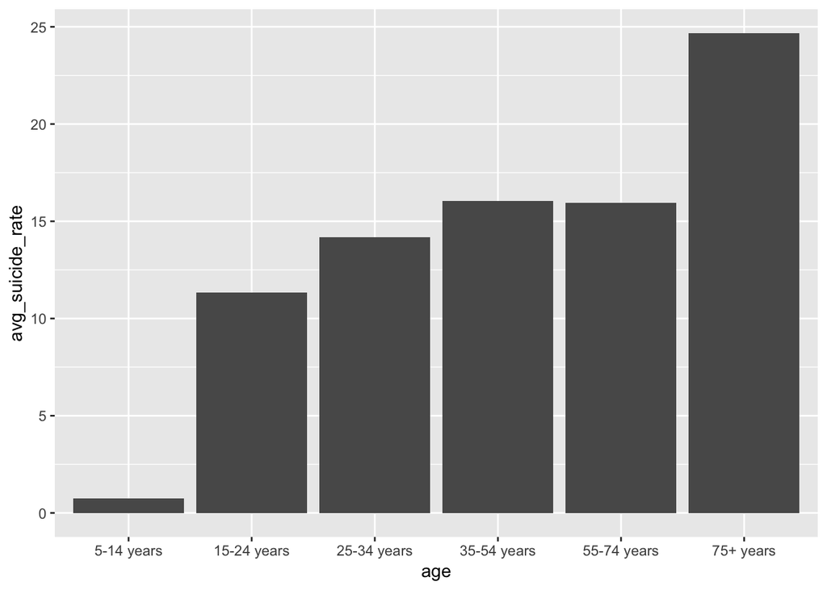

```r
usa_rates %>%
  group_by(age) %>%
  summarize(avg_suicide_rate = mean(suicides_per_100k)) %>%
  ggplot(aes(x= age, y= avg_suicide_rate)) +
    geom_bar(stat = "identity")
```

The bar graph tells us that, between 1985 and 2016, suicides were much higher on average among older members of the population in the U.S., and moderately high for people in their teenage years and older. From this chart it appears that the older people get, the more likely they are to commit suicide.

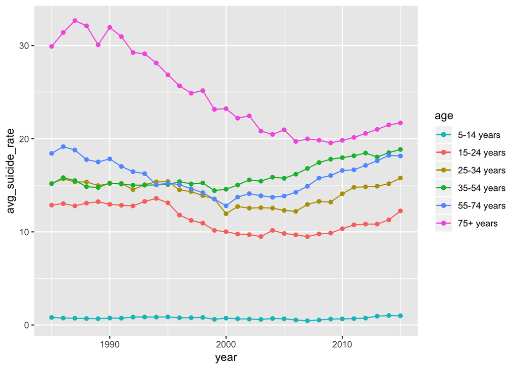

```r
tmp <- usa_rates %>%
  group_by(year, age) %>%
  summarize(avg_suicide_rate = mean(suicides_per_100k)) %>%
  arrange(age)

tmp %>%
  ggplot(aes(x=year, y=avg_suicide_rate, color = age)) +
    geom_point(filter(tmp, age == "5-14 years"), mapping = aes(x=year, y=avg_suicide_rate, color="5-14 years")) +
    geom_line(filter(tmp, age == "5-14 years"), mapping = aes(x=year, y=avg_suicide_rate, color="5-14 years")) +
    geom_point(filter(tmp, age == "15-24 years"), mapping = aes(x=year, y=avg_suicide_rate, color="15-24 years")) +
    geom_line(filter(tmp, age == "15-24 years"), mapping = aes(x=year, y=avg_suicide_rate, color="15-24 years")) +
    geom_point(filter(tmp, age == "25-34 years"), mapping = aes(x=year, y=avg_suicide_rate, color="25-34 years")) +
    geom_line(filter(tmp, age == "25-34 years"), mapping = aes(x=year, y=avg_suicide_rate, color="25-34 years")) +
    geom_point(filter(tmp, age == "35-54 years"), mapping = aes(x=year, y=avg_suicide_rate, color="35-54 years")) +
    geom_line(filter(tmp, age == "35-54 years"), mapping = aes(x=year, y=avg_suicide_rate, color="35-54 years")) +
    geom_point(filter(tmp, age == "55-74 years"), mapping = aes(x=year, y=avg_suicide_rate, color="55-74 years")) +
    geom_line(filter(tmp, age == "55-74 years"), mapping = aes(x=year, y=avg_suicide_rate, color="55-74 years")) +
    geom_point(filter(tmp, age == "75+ years"), mapping = aes(x=year, y=avg_suicide_rate, color="75+ years")) +
    geom_line(filter(tmp, age == "75+ years"), mapping = aes(x=year, y=avg_suicide_rate, color="75+ years")) +
  scale_color_discrete(breaks=c("5-14 years", "15-24 years", "25-34 years", "35-54 years", "55-74 years", "75+ years"))
```

It might be easier to see the difference in trend between each individual group using faceting in the following plot:

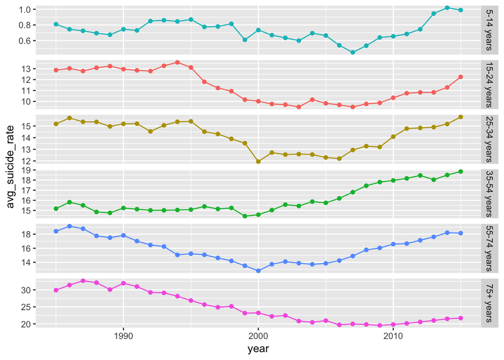

```r
usa_rates %>%
  group_by(year, age) %>%
  summarize(avg_suicide_rate = mean(suicides_per_100k)) %>%
  ggplot(aes(x=year, y=avg_suicide_rate, color = age)) +
    facet_grid(age ~ ., scales = "free") +
    geom_point(filter(tmp, age == "5-14 years"), mapping = aes(x=year, y=avg_suicide_rate, color="5-14 years")) +
    geom_line(filter(tmp, age == "5-14 years"), mapping = aes(x=year, y=avg_suicide_rate, color="5-14 years")) +
    geom_point(filter(tmp, age == "15-24 years"), mapping = aes(x=year, y=avg_suicide_rate, color="15-24 years")) +
    geom_line(filter(tmp, age == "15-24 years"), mapping = aes(x=year, y=avg_suicide_rate, color="15-24 years")) +
    geom_point(filter(tmp, age == "25-34 years"), mapping = aes(x=year, y=avg_suicide_rate, color="25-34 years")) +
    geom_line(filter(tmp, age == "25-34 years"), mapping = aes(x=year, y=avg_suicide_rate, color="25-34 years")) +
    geom_point(filter(tmp, age == "35-54 years"), mapping = aes(x=year, y=avg_suicide_rate, color="35-54 years")) +
    geom_line(filter(tmp, age == "35-54 years"), mapping = aes(x=year, y=avg_suicide_rate, color="35-54 years")) +
    geom_point(filter(tmp, age == "55-74 years"), mapping = aes(x=year, y=avg_suicide_rate, color="55-74 years")) +
    geom_line(filter(tmp, age == "55-74 years"), mapping = aes(x=year, y=avg_suicide_rate, color="55-74 years")) +
    geom_point(filter(tmp, age == "75+ years"), mapping = aes(x=year, y=avg_suicide_rate, color="75+ years")) +
    geom_line(filter(tmp, age == "75+ years"), mapping = aes(x=year, y=avg_suicide_rate, color="75+ years")) +
  theme(legend.position = "none") +
  scale_color_discrete(breaks=c("5-14 years", "15-24 years", "25-34 years", "35-54 years", "55-74 years", "75+ years"))
```

Next let’s look at sex. We can use a similar process to examine this attribute:

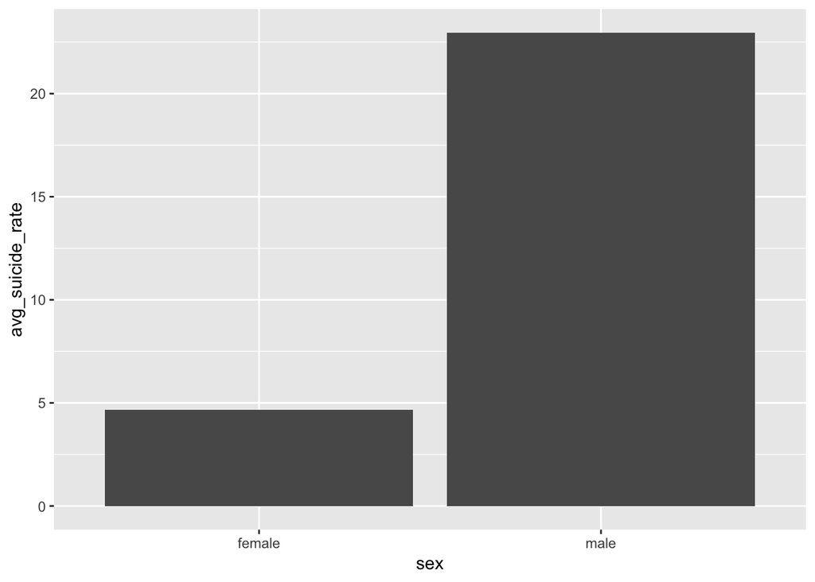

```r
usa_rates %>%
  group_by(sex) %>%
  summarize(avg_suicide_rate = mean(suicides_per_100k)) %>%
  ggplot(aes(x= sex, y= avg_suicide_rate)) +
    geom_bar(stat = "identity")
```

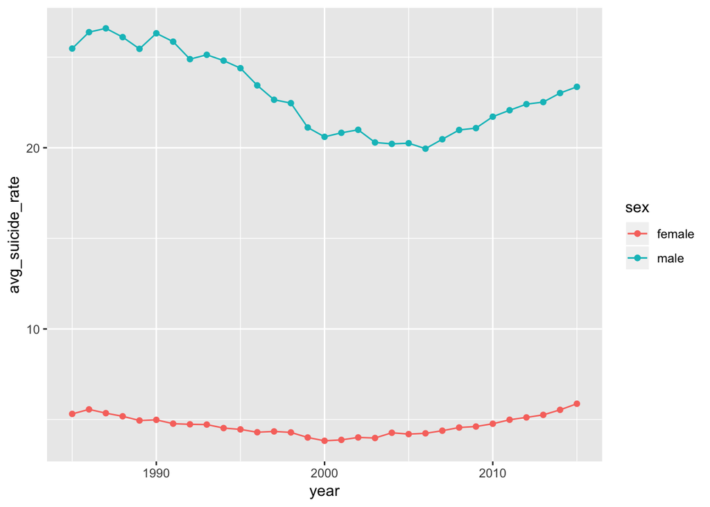

```r
tmp <- usa_rates %>%
  group_by(year, sex) %>%
  summarize(avg_suicide_rate = mean(suicides_per_100k))

tmp %>%
  ggplot(aes(x=year, y=avg_suicide_rate, color=sex)) +
    geom_point(filter(tmp, sex == "male"), mapping = aes(x=year, y=avg_suicide_rate, color="male")) +
    geom_line(filter(tmp, sex == "male"), mapping = aes(x=year, y=avg_suicide_rate, color="male")) +
    geom_point(filter(tmp, sex == "female"), mapping = aes(x=year, y=avg_suicide_rate, color="female")) +
    geom_line(filter(tmp, sex == "female"), mapping = aes(x=year, y=avg_suicide_rate, color="female"))
```

From both plots, it is apparent that in the U.S., men are reported to have committed suicide at significantly higher rates than women. Furthermore, the scatter plot shows us that there is a larger decline in suicides for men while rates for women appear to be somewhat steady with only a slight dip between 1985 and 2000, and an only slight increase from then until 2016.

Let’s look at one final attribute, GDP per capita (2).

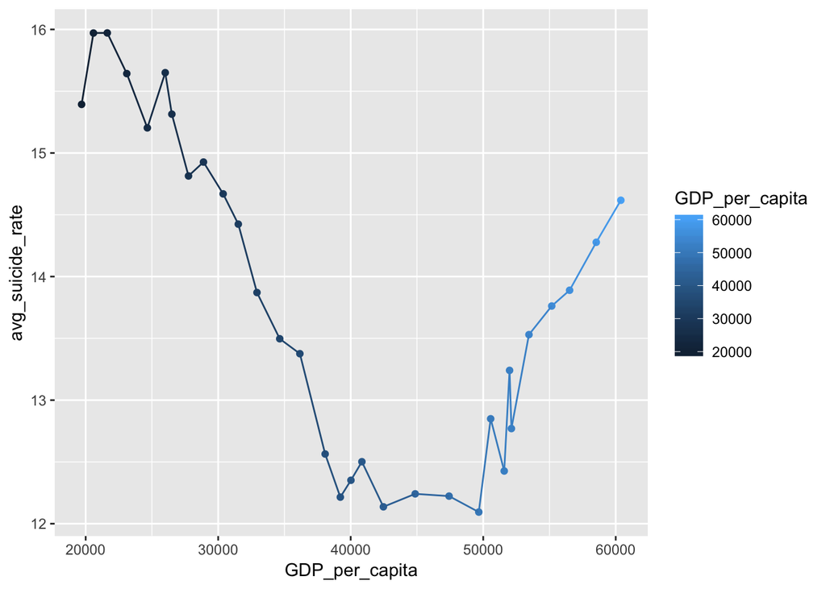

```r
usa_rates %>%
  group_by(GDP_per_capita) %>%
  summarize(avg_suicide_rate = mean(suicides_per_100k)) %>%
  ggplot(aes(x= GDP_per_capita, y= avg_suicide_rate, color=GDP_per_capita)) +
    geom_point() +
    geom_line()
```

This is not what I might have expected to see, but is it interesting to come out with. The rates of suicide are much higher for a much lower GDP in the US, and then they drop significantly for the more intermediate GDP amounts. This suggest that the more the population produces, the fewer suicides tend to have occurred. But then there is dramatic uptick in suicides as the GDP continues to increase. One might have thought that wealth would be better associated with fewer suicides. At least in the United States, this does not appear to be the case.

# Hypothesis Testing (GDP and Suicide Rates)

Even so, it might be interesting to try to go further and see if we can determine between wealthier countries and the rate of suicides (suicide/100k). Perhaps richer countries tend to have lower rates of suicide. To do this, we can apply hypothesis testing to our analysis. We may also want to look at this on a global scale, so we’ll first gather some data regarding all the countries in our dataset, namely average GDP per capita of each country, and average rate of suicide. Our null hypothesis will be that a higher GDP does not have any association or relation with a lower suicide rate.

```r
tmp <- suicide_info %>%
  group_by(country) %>%
  summarize(avg_GDP_per_capita = mean(GDP_per_capita), avg_suicide_rate = mean(suicides_per_100k))

tmp
```

```
## # A tibble: 101 x 3
##    country             avg_GDP_per_capita avg_suicide_rate
##    <chr>                            <dbl>            <dbl>
##  1 Albania                          1859.            3.50
##  2 Antigua and Barbuda             10448.            0.553
##  3 Argentina                        7914.           10.5
##  4 Armenia                          1874.            3.28
##  5 Aruba                           24222.            9.50
##  6 Australia                       32776.           13.0
##  7 Austria                         34262.           23.8
##  8 Azerbaijan                       1005.            1.86
##  9 Bahamas                         25836.            1.25
## 10 Bahrain                         18040.            1.85
## # … with 91 more rows
```

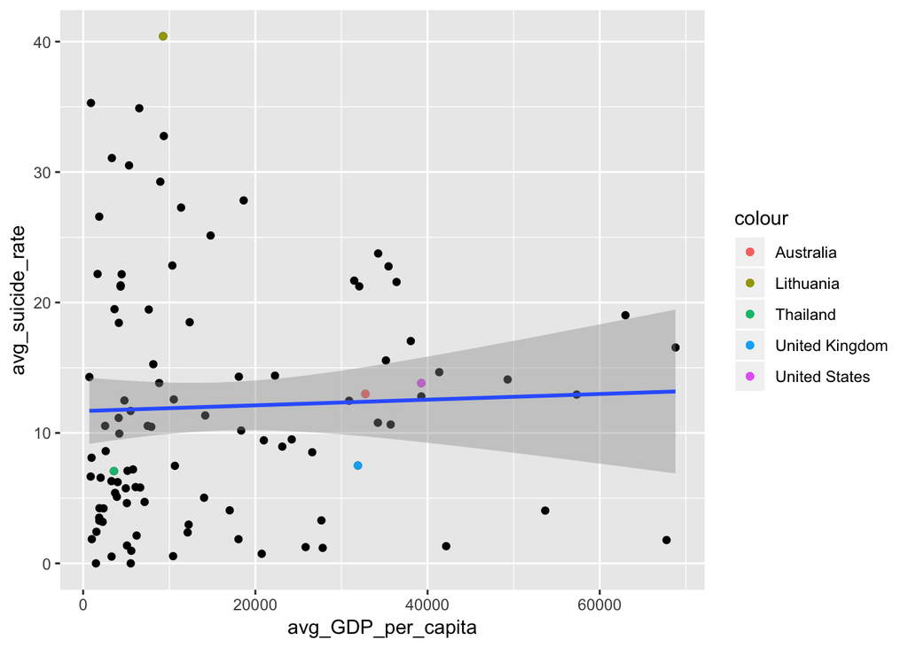

```r
tmp %>%
  ggplot(aes(x=avg_GDP_per_capita, y=avg_suicide_rate)) +
    geom_point() +
    geom_point(filter(tmp, country == "United States"), mapping = aes(x=avg_GDP_per_capita, y=avg_suicide_rate, color="United States")) +
    geom_point(filter(tmp, country == "Lithuania"), mapping = aes(x=avg_GDP_per_capita, y=avg_suicide_rate, color="Lithuania")) +
    geom_point(filter(tmp, country == "United Kingdom"), mapping = aes(x=avg_GDP_per_capita, y=avg_suicide_rate, color="United Kingdom")) +
    geom_point(filter(tmp, country == "Australia"), mapping = aes(x=avg_GDP_per_capita, y=avg_suicide_rate, color="Australia")) +
    geom_point(filter(tmp, country == "Thailand"), mapping = aes(x=avg_GDP_per_capita, y=avg_suicide_rate, color="Thailand")) +
    geom_smooth(method = lm)
```

We’ll try to fit our data with a linear model:

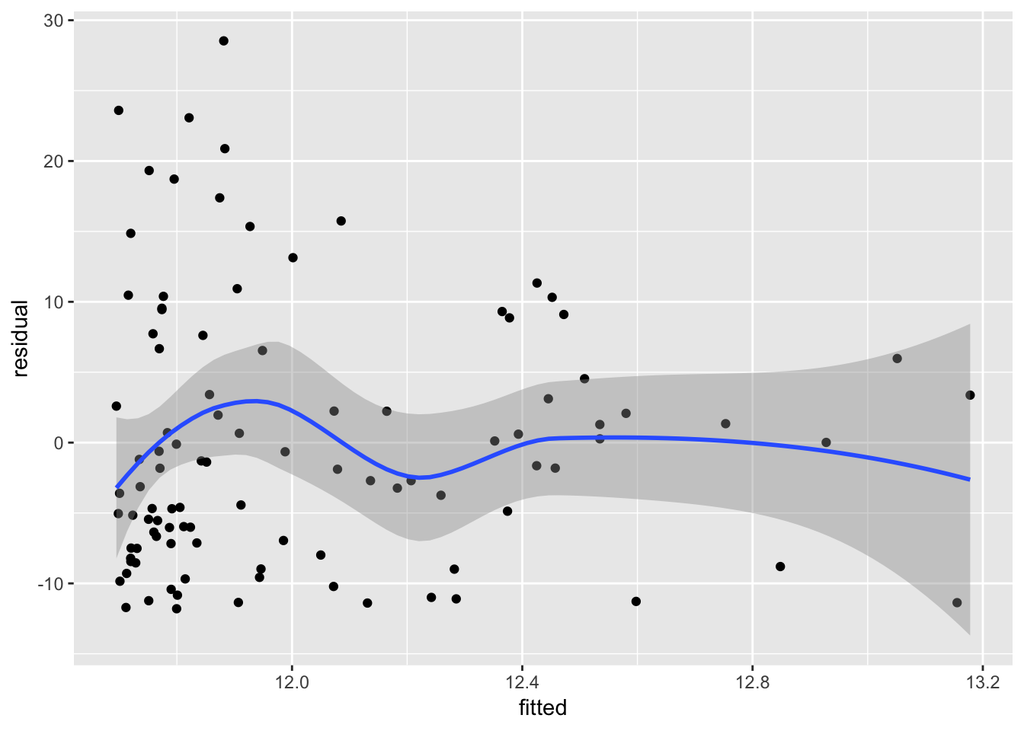

```r
suicide_fit <- lm(avg_suicide_rate ~ avg_GDP_per_capita, data = tmp)

suicide_fit %>%
  augment() %>%
  ggplot(aes(x=.fitted,y=.resid)) +
    geom_point() +
    geom_smooth() +
    labs(x="fitted", y="residual")
```

Unfortunately, this tutorial is incomplete, due to technical and timing issues. What would have come after everything above would have been first an elimination of the outliers to see if that would help a linear model fit our data better. It also would hopefully have given us more focused data to work with (less bias/skew). Additionally, we would have obtained summary statistics to see whether or not the p-value was less than or greater than 0.05 (for a 95% confidence interval). Had what we found been less than 0.05, we would have been able to reject the null hypothesis we states before and say that a higher GDP has some association with lower suicide rates, otherwise we would not reject it.

Notes:

1. HDI or Human Development Index is a measure of “…average achievement in three basic dimensions of human development — a long and healthy life, knowledge and a decent standard of living.” Unfortunately, there is a significant amount of missing data for the countries included in this dataset for this attribute, so we do not use it in our analysis. For more information on this topic, you can visit the following links: http://hdr.undp.org/en/indicators/137506 ; http://hdr.undp.org/sites/default/files/hdr2018_technical_notes.pdf
2. GDP (Gross Domestic Product) is a often used as a measure of the economic output of a country. GDP per capita refers to what each person gives out on average. I chose GDP per capita because the numbers appear much easier to work with (whole numbers vs exponential values), and it provides “…a better indicator of a nation’s living standards since it adjusts for population…an estimate of the standard of living” (https://www.investopedia.com/terms/p/per-capita-gdp.asp).
3. Several countries were excluded from this dataset including China, the majority of Africa, India, and many others (noted by Grecnik in the Kaggle discussion of the dataset: https://www.kaggle.com/russellyates88/suicide-rates-overview-1985-to-2016/discussion/82269).